# monet_fticr

VGC

2025-01-20

## Get data ready for analysis

### 1- Reading in the data

Read-in Processed MONet FTICR-MS and Biogeochemistry data

### 2- Merge replicates and Clean up Data

Merge replicate where you keep a molecular formula if it was present in at least 2 out of the 3 samples replicates for that site and core location.

### 3- Calculate Average Molecular Indices in the merged file

### 4- Calculate Relevative Abundance for Elemental composition and for Compound Classes

## Analyze data

#### H1: TOP layer will be richer (total number of peaks with MF assigned), more diverse and higher WEOM concentration than BTM layer. Thus the TOP layer will have higher respiration than BTM.

#### Richness

Evaluate richness as the total number of molecular formula assigned within all top and bottom samples and do a boxplot where points are sample level total number of peaks categorically colors by top or bottom.

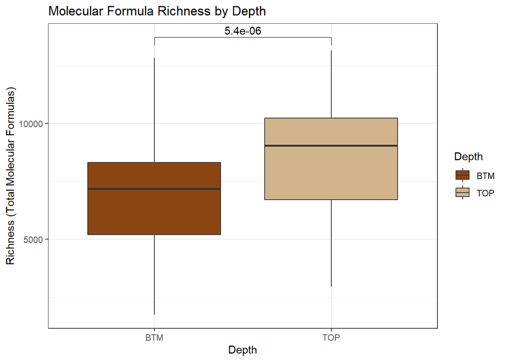

```r
# Perform t-test to compare richness between TOP and BTM
t_test_result <- t.test(total_formulas ~ Depth, data = mol_properties_average)

# Define colorblind-friendly soil colors
soil_colors <- c("TOP" = "#D2B48C", "BTM" = "#8B4513")  # Lighter brown for TOP, darker brown for BTM


# Create the boxplot with statistical test
plot <- ggplot(mol_properties_average, aes(x = Depth, y = total_formulas, fill = Depth)) +
  geom_boxplot() +
  labs(
    title = "Molecular Formula Richness by Depth",
    x = "Depth",
    y = "Richness (Total Molecular Formulas)"
  ) +
  theme_bw() +
  scale_fill_manual(values = soil_colors) +
  stat_compare_means(comparisons = list(c("TOP", "BTM")), method = "t.test", label = "p.format")

# Print the plot
print(plot)
```

#### Diversity in a multivariate space

##### NMDS

Use only peaks to plot and color by top and bottom in a NMDS space plot color by TOP and BTM ## NMDS

```r
set.seed(1988)
#Run NMDS using Jaccard distance for the presence/absence data and bray-curtis for the hellinger(abundance data)
dist = vegdist(x = t(merged_fticr_data), method = "jaccard")

# Plotting Jaccard NMDS
nms = metaMDS(dist, trymax = 1000) # Determining NMDS
```

```
## *** Best solution repeated 1 times
```

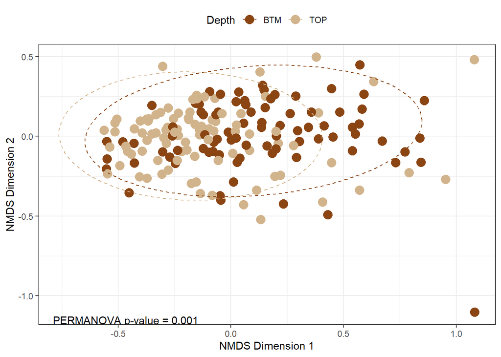

```r
nms = as.data.frame(scores(nms)) # Converting to scores
factors = mol_properties_average %>% dplyr::select(Sample_ID,Depth)
nms = cbind(factors, nms)

#Perform PERMANOVA
depth = as.factor(nms$Depth)
permanova = adonis2(t(merged_fticr_data) ~ depth, method = "jaccard", permutations = 999)

# Extract the p-value from the PERMANOVA results
permanova_pvalue = permanova$`Pr(>F)`[1]

#Plot
plot <- nms %>%
  ggplot(aes(x = NMDS1, y = NMDS2)) +
  geom_point(aes(color = Depth), size = 4) +
  stat_ellipse(aes(color = Depth), level = 0.95, linetype = 2) +
  scale_color_manual(values = soil_colors) +
  theme_bw() +
  theme(legend.position = "top") +
  labs(
    x = "NMDS Dimension 1",
    y = "NMDS Dimension 2") +
annotate("text", x = -Inf, y = -Inf, label = paste("PERMANOVA p-value =", format.pval(permanova_pvalue)), hjust = -0.1, vjust = -0.1)

# Print the plot
print(plot)
```

#### PCA

Use molecular characteristics (AImod, DBE, etc) as your matrix for a PCA to plot color by TOP and BTM

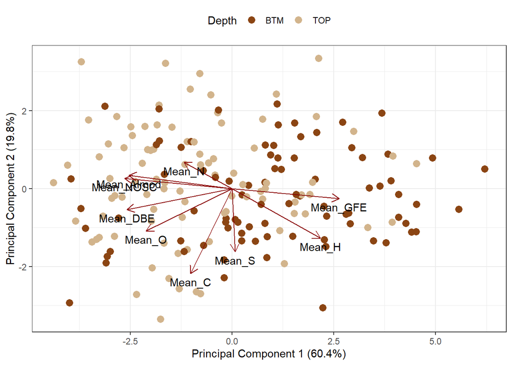

```r
chemical_data = mol_properties_average %>%
  dplyr::select(c(-Proposal_ID,-Sample_ID,-Depth, -Sample_number,-total_formulas, -Mean_P))

pca_result <- prcomp(chemical_data, scale. = TRUE)

# Create a data frame with PCA results
pca_scores <- as.data.frame(pca_result$x)
pca_loadings <- as.data.frame(pca_result$rotation)

# Add PCA scores to factors
pca_dat <- cbind(factors, pca_scores)

# Calculate the percentage of variance explained by each PC
percent_variance <- round(100 * pca_result$sdev^2 / sum(pca_result$sdev^2), 1)

# Create the PCA plot with loadings as arrows
pca_plot <- ggplot(pca_dat, aes(x = PC1, y = PC2, color = Depth)) +
  geom_point(size = 3) +
  scale_color_manual(values = soil_colors) +
  theme_bw() +
  labs( x = paste0("Principal Component 1 (", percent_variance[1], "%)"),
       y = paste0("Principal Component 2 (", percent_variance[2], "%)")) +
  theme(legend.position = "top") +
  geom_segment(data = pca_loadings, aes(x = 0, y = 0, xend = PC1 * max(pca_scores$PC1),
                                        yend = PC2 * max(pca_scores$PC2)),
               arrow = arrow(length = unit(0.3, "cm")), color = "darkred") +
  geom_text(data = pca_loadings, aes(x = PC1 * max(pca_scores$PC1),
                                     y = PC2 * max(pca_scores$PC2),
                                     label = rownames(pca_loadings)), color = "black", vjust = 1.5)

print(pca_plot)
```

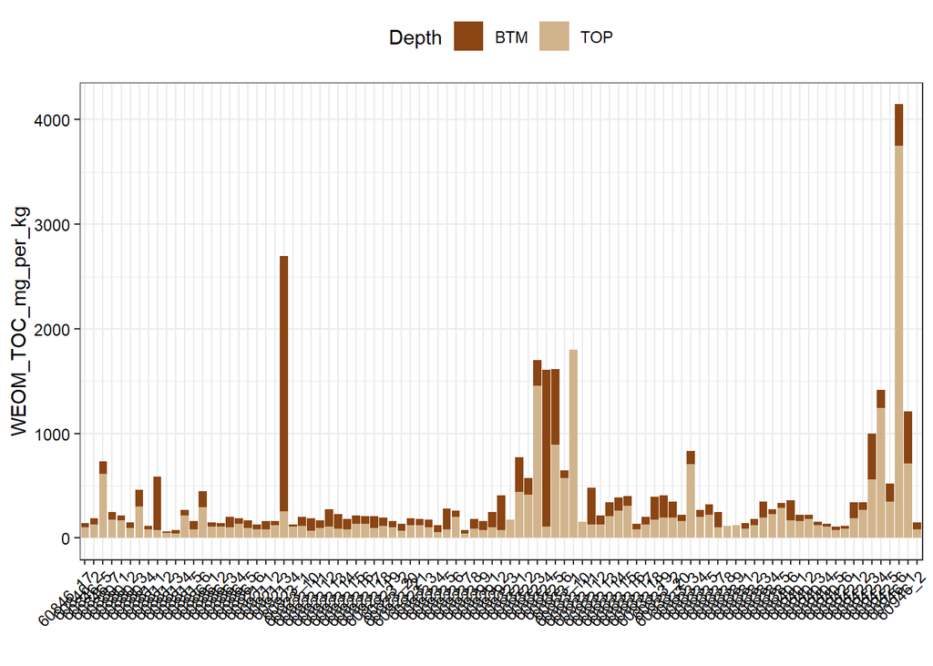

```r
biogeochem$Depth <- biogeochem$Core_Section
biogeochem = biogeochem %>%
  filter(!is.na(WEOM_TOC_mg_per_kg))

biogeochem$Sample_combination = sub("_[^_]+_[^_]+$", "", biogeochem$Sample_Name)
biogeochem$Sample_ID = sub("_[^_]+$", "", biogeochem$Sample_Name)

# Generate the boxplot
ggplot(biogeochem, aes(x = Sample_combination, y = as.numeric(`WEOM_TOC_mg_per_kg`), fill = Depth)) +
  geom_bar(stat = 'identity') +
  labs(x = '', y = "WEOM_TOC_mg_per_kg") +
  theme_bw()+
    theme(axis.text.x = element_text(angle = 45, hjust = 1, color = "black"),
        axis.text.y = element_text(color = "black"),
        axis.title.x = element_text(color = "black"),
        axis.title.y = element_text(color = "black"),
        plot.title = element_text(color = "black"),
        legend.position = "top") +
  scale_fill_manual(values = c("TOP" = "#D2B48C", "BTM" = "#8B4513"))  # Lighter brown for TOP, darker brown for BTM
```

#### Correlations

Correlation between richness(number of peaks with molecular formula assigned in a sample) and WEOM for each top and bottom.

Plotting Pearson correlations

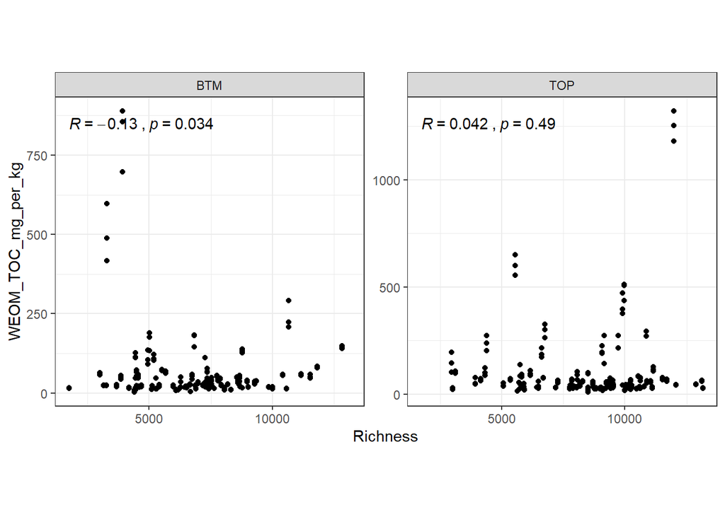

```r
data_cor = merge(mol_properties_average,biogeochem, by = c('Sample_ID','Depth'))
data_cor = data_cor %>%
  dplyr::select(Depth,total_formulas,WEOM_TOC_mg_per_kg)


ggplot(data_cor, aes(x = total_formulas, y = WEOM_TOC_mg_per_kg)) +
  geom_point() +
  facet_wrap(~ Depth, scales = 'free_y') +
  labs( x = "Richness",
       y = "WEOM_TOC_mg_per_kg") +
  theme_bw() +
    stat_cor(method = "pearson", aes(label = paste(..r.label.., ..p.label.., sep = "~`,`~")), label.x.npc = "left", label.y.npc = "top") +
 theme(aspect.ratio = 1)
```

#### Boxplot of GFE and NOSC

[LaRowe and Van Cappellen, 2012](https://www.sciencedirect.com/science/article/pii/S0016703711000378) found an empirical relationship between the Gibbs Free Energy of C oxidation at standard state (GFE) and the nominal oxidation state of C (NOSC).*Lower values of GFE (i.e., lower magnitudes are more thermodynamically favorable.*

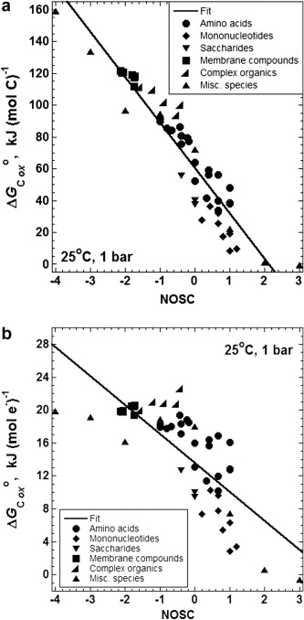

Image from LaRowe and Van Capellen 2012. Standard molal Gibbs energies of the oxidation half reactions of organic compounds as a function of the average nominal oxidation state of carbon (NOSC) in the compounds, at 25 °C and 1 bar. The Gibbs energies are expressed in kJ per mole of carbon (a) and kJ per mole of electrons transferred (b)

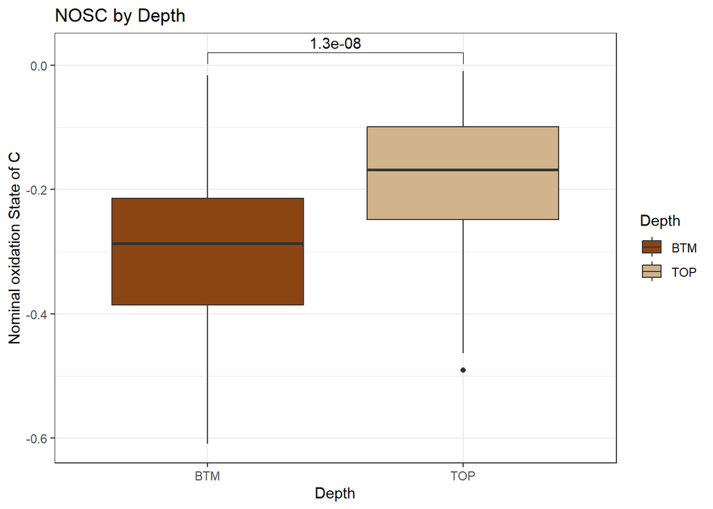

```r
# Create the boxplot of mean values with statistical test
# NOSC
ggplot(mol_properties_average, aes(x = Depth, y = as.numeric(Mean_NOSC), fill = Depth)) +
  geom_boxplot() +
  labs(
    title = "NOSC by Depth",
    x = "Depth",
    y = "Nominal oxidation State of C"
  ) +
  theme_bw() +
  scale_fill_manual(values = soil_colors) +
  stat_compare_means(comparisons = list(c("TOP", "BTM")), method = "t.test", label = "p.format")
```

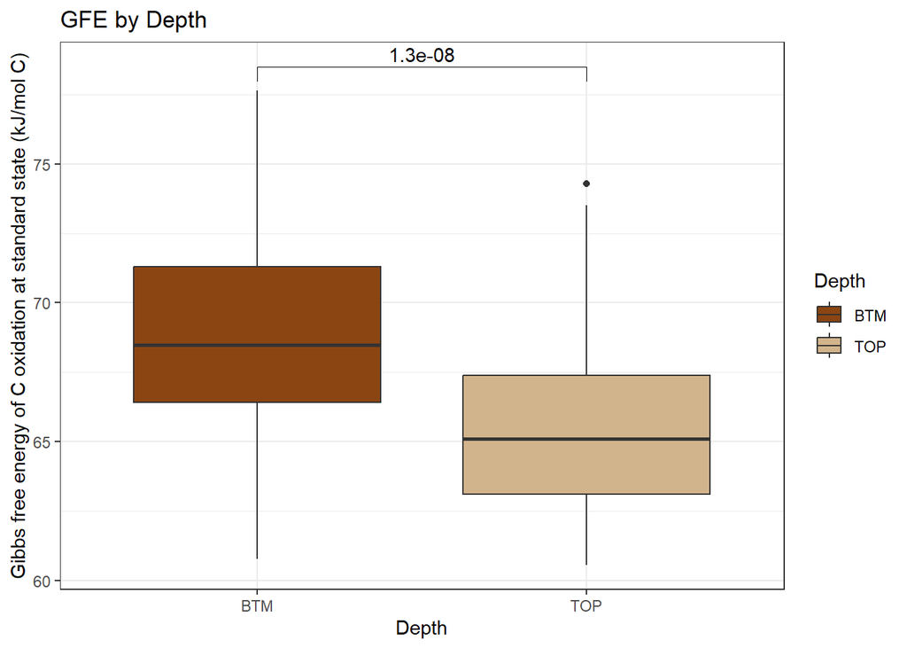

```r
# GFE
ggplot(mol_properties_average, aes(x = Depth, y = as.numeric(Mean_GFE), fill = Depth)) +
  geom_boxplot() +
  labs(
    title = "GFE by Depth",
    x = "Depth",
    y = "Gibbs free energy of C oxidation at standard state (kJ/mol C)"
  ) +
  theme_bw() +
  scale_fill_manual(values = soil_colors) +
  stat_compare_means(comparisons = list(c("TOP", "BTM")), method = "t.test", label = "p.format")
```

#### WEOM Boxplots

Looking at water extractable C across depths

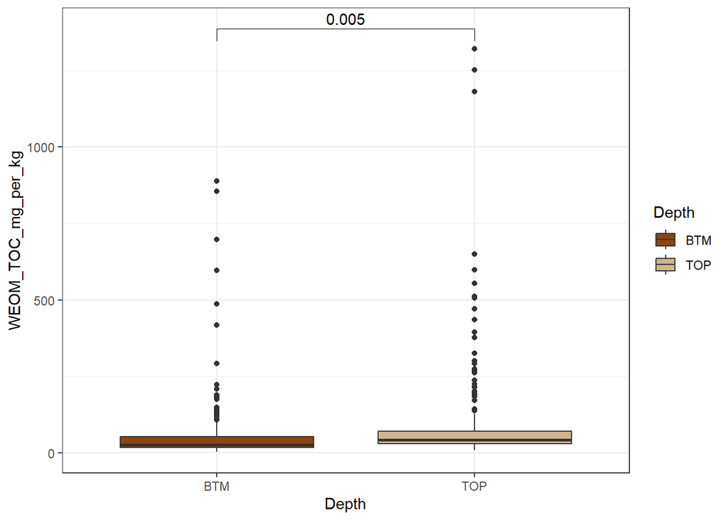

```r
# Create the main plot with zoom
main_plot <- ggplot(biogeochem, aes(x = Depth, y = WEOM_TOC_mg_per_kg, fill = Depth)) +
  geom_boxplot() +
  labs(
    x = "Depth",
    y = "WEOM_TOC_mg_per_kg"
  ) +
  scale_fill_manual(values = soil_colors) +
  theme_bw() +
  stat_compare_means(comparisons = list(c("TOP", "BTM")), method = "t.test", label = "p.format")

print(main_plot)
```